# Háromtest-probléma Szimuláció Pythonban

Kovács László

2024-04-07

## 1. A bolygók pályáját leíró differenciálegyenletek

Először vesszük a Newton-féle gravitációs törvényt. Gravitációs erő ($F$) nagyságát adja meg két pontszerű test között.

$$F=G\frac{m_1m_2}{r^3}$$
Ahol - $G$ a gravitációs állandó $6.67408\times10^{-11}Nm^2kg^{-2}$ - $m_1,m_2$ a két test tömege (kg) - $r$ a két test tömegközéppontja közti távolság (m)

Newton II. törvénye szerint ugyanakkor egy mozgó testre ható erő ($F$) nagysága megegyezik a test tömegének és gyorsulásának szorzatával. A gyorsulás pedig a megtett út (tehát a test helyzetét a $t$ időpontban megadó $\vec{r_1}$ vektor) idő ($t$) szerinti második deriváltja.  
Mindezt alkalmazva az első testünkre kapjuk az alábbi összefüggést.

$$F=m_1
\frac{\partial^2{\vec{r_1}}}{\partial{t^2}}$$

Ezt a két összefüggést összeeresztve kapjuk az első test helyzetét a $t$ időpontban megadó $\vec{r_1}$ vektorra felírható másodrendű differenciálegyenletet.

$$m_1
\frac{\partial^2{\vec{r_1}}}{\partial{t^2}}=G\frac{m_1m_2}{r^3}$$

Ha ezt megoldjuk, akkor minden $t$ időpontra tudjuk, hogy hol van az első testünk.

Ezt hasonló módon a második test helyzetét $t$ időpontra leíró $\vec{r_2}$ vektorra is el tudjuk sütni.

$$m_2
\frac{\partial^2{\vec{r_2}}}{\partial{t^2}}=G\frac{m_1m_2}{r^3}$$

Oké, de ez eddig csak két test. Hogy lesz ebből három test?

Egyszerűen csak az történik, hogy az éppen vizsgált testünk nem egy másikkal áll kölcsönhatásba, hanem kettővel. Tehát, a differenciálegyenletek jobb oldalán a Newton-féle gravitációs törvények összegét kell venni arra a két test-párosra, amivel az aktuális testünk éppen kapcsolatban áll. Pl. a második test esetén az alábbi módon.

$$m_2
\frac{\partial^2{\vec{r_2}}}{\partial{t^2}}=G\frac{m_1m_2}{r_{12}^3}+G\frac{m_2m_3}{r_{23}^3}$$

Ahol természetesen $m_3$ a harmadik test tömege és $r_{12}$ valamint $r_{23}$ rendre az első és második valamint második és harmadik test közti távolság.

Általános alakban a differenciálegyenlet az $i$-edik testre a következő módon adható meg ($G$ kiemelése után a jobboldalon).

$$m_i
\frac{\partial^2{\vec{r_i}}}{\partial{t^2}}=G\sum_j{\frac{m_im_j}{r_{ij}^3}}$$

Numerikus differenciálegyenlet megoldás könnyebben megy a megoldóprogramoknak (így a Python `scipy` könyvtárnak is majd), ha a differenciálegynletek nem másodrendűek, hanem elsőrendűek. Így felhasználjuk, hogy a gyorsulás a sebesség $v$ idő szerinti első deriváltja, és a sebesség a megtett út (tehát a test helyzetét a $t$ időpontban megadó $\vec{r_1}$ vektor) idő szerinti első deriváltja.  
Ezzel minden testre két differenciálegyenletünk lesz, de ezek már külön-külön elsőrendűek.

$$m_i
\frac{\partial{\vec{v_i}}}{\partial{t}}=G\sum_j{\frac{m_im_j}{r_{ij}^3}}$$
$$\frac{\partial{\vec{r_i}}}{\partial{t}}=\vec{v_i}$$

## 2. Szimulációhoz használt adatok

Először egy kétbolygós rendszerből indulunk (kéttest probléma). Adatoknak az [Alfa Centauri csillagrendszer](https://hu.wikipedia.org/wiki/Alfa_Centauri) két legfényesebb csillagát használjuk.

A numerikus differenciálegyenlet megoldás megkönnyítése miatt minden adatot a Nap adatainak százalékában fejezünk ki. Ehhez a differenciálegyenleteink jobb oldalát $K_1$ és $K_2$ szorzókkal skálázzuk át, így a testek pályáját leíró differenciálegyenletek az alábbi alakra módosulnak.

$$m_i
\frac{\partial{\vec{v_i}}}{\partial{t}}=K_1\sum_j{\frac{m_im_j}{r_{ij}^3}}$$
$$\frac{\partial{\vec{r_i}}}{\partial{t}}=K_2\vec{v_i}$$

A Nap százalékára való átváltást kifejező $K_1$ és $K_2$ szorzókat az Alfa Centauri csillagrendszer esetében az alábbi módon tudjuk kiszámolni. Az eredményeket Python objektumként el is mentjük.

```python
G=6.67408e-11 # N-m2/kg2 --> gravitációs állandó

# Referencia mennyiségek
m_nd=1.989e+30 # kg --> Nap tömege
r_nd=5.326e+12 # m --> az Alfa Centauri két legfényesebb csillagának távolsága
v_nd=30000 # m/s --> a Föld relatív sebessége a Nap körül
t_nd=79.91*365*24*3600*0.51 # mp --> az Alfa Centauri orbitális periódusa

# Skálázó szorzók megadása
K1=G*t_nd*m_nd/(r_nd**2*v_nd)
K2=v_nd*t_nd/r_nd
```

A továbbiakban már szükségünk lesz több külső Python könyvtárra is. Ezeket most importáljuk.

```python
# Számítások
import scipy as sci
import scipy.integrate

# Rajzolás
import matplotlib.pyplot as plt
from mpl_toolkits.mplot3d import Axes3D
from matplotlib import animation
```

Az egyéb kezdeti adatokat az alábbi Python objektumokkal adjuk meg. Arra figyeljünk, hogy a csillagok esetében 3D-ben mozgunk. Tehát, minden utat és sebebességet leíró $\vec{r_i}$ és $\vec{v_i}$ vektornak három koordinátája van. Azaz, $\vec{r_i}=[x,y,z]$ és $\vec{v_i}=[x,y,z]$.

Első körben a kéttest-problémából indulunk.

```python
m1=1.1 # az Alfa Centauri 'A' csillag tömege a Nap tömegének százalékában
m2=0.907 # az Alfa Centauri 'A' csillag tömege a Nap tömegének százalékában

# A csillagok kezdeti helyét leíró 3D vektorok
r1=[-0.5,0,0] # m
r2=[0.5,0,0] # m

# A kezdeti koordináták 1D Python tömbbé konvertálása (technikai lépés)
r1=sci.array(r1,dtype="float64")
r2=sci.array(r2,dtype="float64")

# A csillagok kezdeti sebességét leíró 3D vektorok
v1=[0.01,0.01,0] # m/s
v2=[-0.05,0,-0.1] # m/s

# A kezdeti sebességek 1D Python tömbbé konvertálása (technikai lépés)
v1=sci.array(v1,dtype="float64")
v2=sci.array(v2,dtype="float64")
```

## 3. Kéttest-probléma differenciálegyenlet megoldás

A differenciálegyenleteket leíró függvény definiálása.

```python
def KetTest(w,t,G,m1,m2):
    # 3D megoldásvektorok definíciója a két test helyére/útjára (r) és sebességére (v)
    r1=w[:3]
    r2=w[3:6]
    v1=w[6:9]
    v2=w[9:12]

    r=sci.linalg.norm(r2-r1) # Két test között megtett út hosszának megadása

    # differenciálegyenletek leírása
    dv1bydt=K1*m2*(r2-r1)/r**3
    dv2bydt=K1*m1*(r1-r2)/r**3
    dr1bydt=K2*v1
    dr2bydt=K2*v2

    # differenciálegyenlet objektumok listába fűzése és visszaadása
    r_derivs=sci.concatenate((dr1bydt,dr2bydt))
    derivs=sci.concatenate((r_derivs,dv1bydt,dv2bydt))
    return derivs
```

A differenciálegyenletek megoldása numerikus integrálással.

```python
init_params=sci.array([r1,r2,v1,v2]) # kezdeti értékek egy 4D tömbbe fűzése
init_params=init_params.flatten() # kezdeti értékek tömbjének 1D-be konvertálása (technikai lépés)
time_span=sci.linspace(0,8,500) # 8 orbitális periódusra 500 helyvektor megoldást kérünk le a numerikus integrálással

# differenciálegyenlet megoldás numerikus integrálással
kettest_eredmeny = sci.integrate.odeint(KetTest,init_params,time_span,args=(G,m1,m2))
```

Az eredményből nekünk csak a két test helyére/útjára (azaz $\vec{r_1}$-re és $\vec{r_2}$-re) vonatkozó megoldások kellenek (3D-ben). Ezeket mentsük ki külön objektumokba.

```python
r1_eredmeny = kettest_eredmeny[:,:3]
r2_eredmeny = kettest_eredmeny[:,3:6]
```

Megoldás ábrázolása 3D koordináta-rendszerben.

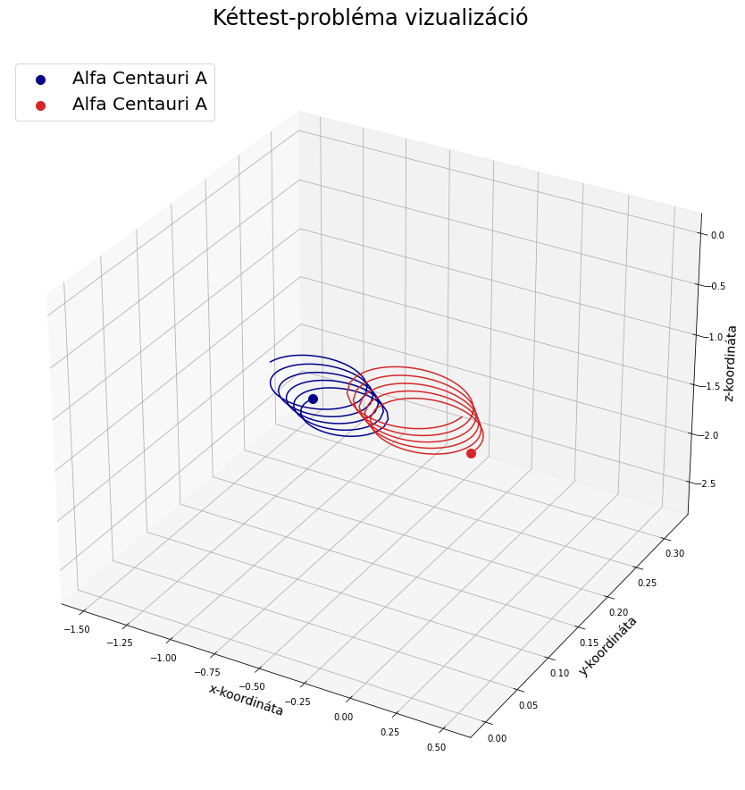

```python
# 15x15 ábrakeret létrehozása
fig=plt.figure(figsize=(15,15))

# Tengelyek felvétele az ábrára
ax=fig.add_subplot(111,projection="3d")

# Helyvektorok = Orbitális pályák megadása a két bolygóra
ax.plot(r1_eredmeny[:,0],r1_eredmeny[:,1],r1_eredmeny[:,2],color="darkblue")
ax.plot(r2_eredmeny[:,0],r2_eredmeny[:,1],r2_eredmeny[:,2],color="tab:red")

# Utolsó időpontban vett pozíció megjelelölése ponttal
ax.scatter(r1_eredmeny[-1,0],r1_eredmeny[-1,1],r1_eredmeny[-1,2],color="darkblue",marker="o",s=100,label="Alfa Centauri A")
ax.scatter(r2_eredmeny[-1,0],r2_eredmeny[-1,1],r2_eredmeny[-1,2],color="tab:red",marker="o",s=100,label="Alfa Centauri A")

# Tengelyfeliratok felvétele
ax.set_xlabel("x-koordináta",fontsize=14)
ax.set_ylabel("y-koordináta",fontsize=14)
ax.set_zlabel("z-koordináta",fontsize=14)
ax.set_title("Kéttest-probléma vizualizáció\n",fontsize=24)
ax.legend(loc="upper left",fontsize=20)
```

Ez még két egészen stabil pályának néz ki.

## 4. Háromtest-probléma differenciálegyenlet megoldás

Dobjunk be a rendszerbe egy fiktív, harmadik csillagot! Először felvesszük a harmadik csillag adatait.

```python
m3=1.0 # a harmadik csillag tömege a Nap tömegének százalékában

# a harmadik csillag kezdeti pozíciója
r3=[0,1,0] # m
r3=sci.array(r3,dtype="float64")

# a harmadik csillag kezdeti sebessége
v3=[0,-0.01,0]
v3=sci.array(v3,dtype="float64")
```

A differenciálegyenleteket leíró függvény bővítése a harmadik testtel

```python
def HaromTest(w,t,G,m1,m2,m3):
    # 3D megoldásvektorok definíciója a három test helyére/útjára (r) és sebességére (v)
    r1=w[:3]
    r2=w[3:6]
    r3=w[6:9]
    v1=w[9:12]
    v2=w[12:15]
    v3=w[15:18]

    # Megtett utak megadása
    r12=sci.linalg.norm(r2-r1)
    r13=sci.linalg.norm(r3-r1)
    r23=sci.linalg.norm(r3-r2)

    # differenciálegyenletek leírása
    dv1bydt=K1*m2*(r2-r1)/r12**3+K1*m3*(r3-r1)/r13**3
    dv2bydt=K1*m1*(r1-r2)/r12**3+K1*m3*(r3-r2)/r23**3
    dv3bydt=K1*m1*(r1-r3)/r13**3+K1*m2*(r2-r3)/r23**3
    dr1bydt=K2*v1
    dr2bydt=K2*v2
    dr3bydt=K2*v3

    # differenciálegyenlet objektumok listába fűzése és visszaadása
    r12_derivs=sci.concatenate((dr1bydt,dr2bydt))
    r_derivs=sci.concatenate((r12_derivs,dr3bydt))
    v12_derivs=sci.concatenate((dv1bydt,dv2bydt))
    v_derivs=sci.concatenate((v12_derivs,dv3bydt))
    derivs=sci.concatenate((r_derivs,v_derivs))
    return derivs
```

A differenciálegyenletek megoldása numerikus integrálással.

```python
init_params=sci.array([r1,r2,r3,v1,v2,v3]) # kezdeti értékek egy 4D tömbbe fűzése
init_params=init_params.flatten() # kezdeti értékek tömbjének 1D-be konvertálása (technikai lépés)
time_span=sci.linspace(0, 20,500) # 20 orbitális periódusra 500 helyvektor megoldást kérünk le a numerikus integrálással

# differenciálegyenlet megoldás numerikus integrálással
haromtest_eredmeny = sci.integrate.odeint(HaromTest,init_params,time_span,args=(G,m1,m2,m3))
```

Az eredményből nekünk csak a három test helyére/útjára (azaz $\vec{r_1}$-re, $\vec{r_2}$-re és $\vec{r_3}$-ra) vonatkozó megoldások kellenek (3D-ben). Ezeket mentsük ki külön objektumokba.

```python
r1_eredmeny = haromtest_eredmeny[:,:3]
r2_eredmeny = haromtest_eredmeny[:,3:6]
r3_eredmeny = haromtest_eredmeny[:,6:9]
```

Megoldás ábrázolása 3D koordináta-rendszerben.

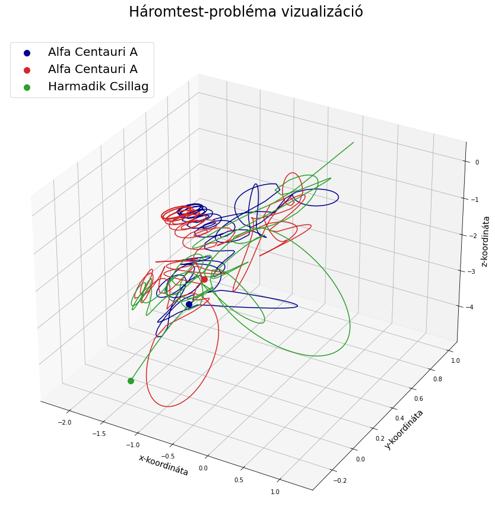

```python
# 15x15 ábrakeret létrehozása
fig=plt.figure(figsize=(15,15))

# Tengelyek felvétele az ábrára
ax=fig.add_subplot(111,projection="3d")

# Helyvektorok = Orbitális pályák megadása a három bolygóra
ax.plot(r1_eredmeny[:,0],r1_eredmeny[:,1],r1_eredmeny[:,2],color="darkblue")
ax.plot(r2_eredmeny[:,0],r2_eredmeny[:,1],r2_eredmeny[:,2],color="tab:red")
ax.plot(r3_eredmeny[:,0],r3_eredmeny[:,1],r3_eredmeny[:,2],color="tab:green")

# Utolsó időpontban vett pozíció megjelelölése ponttal
ax.scatter(r1_eredmeny[-1,0],r1_eredmeny[-1,1],r1_eredmeny[-1,2],color="darkblue",marker="o",s=100,label="Alfa Centauri A")
ax.scatter(r2_eredmeny[-1,0],r2_eredmeny[-1,1],r2_eredmeny[-1,2],color="tab:red",marker="o",s=100,label="Alfa Centauri A")
ax.scatter(r3_eredmeny[-1,0],r3_eredmeny[-1,1],r3_eredmeny[-1,2],color="tab:green",marker="o",s=100,label="Harmadik Csillag")

# Tengelyfeliratok felvétele
ax.set_xlabel("x-koordináta",fontsize=14)
ax.set_ylabel("y-koordináta",fontsize=14)
ax.set_zlabel("z-koordináta",fontsize=14)
ax.set_title("Háromtest-probléma vizualizáció\n",fontsize=24)
ax.legend(loc="upper left",fontsize=20)
```

Három testtel az élet már elég **kaotikus**! :)